# Colchicine Pilot Trial — Statistical Results

July 23, 2026

# Colchicine Pilot Trial — Statistical Results

Protocol: [STUDY-21-001175](https://clinicaltrials.gov/study/NCT05279690), version 3.0 (22 May 2023) | Trial registration: NCT05279690 | Data cut: 23 July 2026

## Primary Assessment Method

Table 1. Primary assessment method.

[output not shown]

## Accrual Disposition

All 16 subjects who signed informed consent underwent screening evaluation. Protocol v3.0 specified two Cohort 1 treatment schedules: the original schedule (indefinite on-study colchicine with serial imaging surveillance) and a fixed 2-week course without transitioning patients already on the original schedule. 7 enrolled patients are included in Kaplan–Meier progression-free and overall survival analyses; 4 enrolled on the fixed 2-week schedule contributed to toxicity and primary CRP analyses but were excluded from survival estimates because they did not follow the same longitudinal imaging schedule. When organ-function or CRP thresholds were not met, the report states the clinical reason for screen failure and the screening laboratory value when available.

Table 2. Accrual disposition among consented subjects.

| Disposition | N | N (%) |
| --- | --- | --- |
| Signed informed consent | 16 | 16 |
| Enrolled on study | 11 | 11 (68.8% of consented) |
| Original schedule (indefinite colchicine + surveillance imaging) | 7 | 7 (Kaplan–Meier–evaluable) |
| Fixed 2-week schedule (phase 0 intervention) | 4 | 4 (primary CRP / toxicity only) |
| Screen failure before enrollment | 5 | 5 (31.2% of consented) |
| Original schedule | 3 | 3 (Kaplan–Meier–evaluable) |
| Fixed 2-week schedule | 2 | 2 (primary CRP / toxicity only) |

Table 3. Reasons for screen failure before enrollment.

| Screen-failure reason | N | N (%) | Details |
| --- | --- | --- | --- |
| Patient decision to discontinue | 2 | 2 (12.5% of consented) | Screening category: Patient decision to discontinue |
| CRP below inclusion threshold | 1 | 1 (6.2% of consented) | CRP 4.6 mg/L (required >5 mg/L) |
| Inadequate organ function | 1 | 1 (6.2% of consented) | Did not meet inclusion organ-function criteria; creatinine 2.05 mg/dL (required <=1.5 mg/dL) |
| Other | 1 | 1 (6.2% of consented) | admitted same day as ICF signing (3/29/22) - SAE of bronchopulmonary hemorrhage |

Table 4. Screen-failure subjects: reason and supporting detail.

| Consent date | Screen-failure reason | Details |
| --- | --- | --- |
| 2022-02-24 | Patient decision to discontinue | Screening category: Patient decision to discontinue |
| 2022-03-29 | Other | admitted same day as ICF signing (3/29/22) - SAE of bronchopulmonary hemorrhage |
| 2022-04-13 | Inadequate organ function | Did not meet inclusion organ-function criteria; creatinine 2.05 mg/dL (required <=1.5 mg/dL) |
| 2022-10-25 | Patient decision to discontinue | Screening category: Patient decision to discontinue |
| 2023-10-11 | CRP below inclusion threshold | CRP 4.6 mg/L (required >5 mg/L) |

## Patient Characteristics

Table 5. Patient characteristics (Cohort 1 low dose).

| Characteristic | Value |
| --- | --- |
| Number enrolled (Cohort 1 low dose) | 11 |
| Sex, male, n (%) | 4 (36.4%) |
| Sex, female, n (%) | 7 (63.6%) |
| Age at enrollment, median (range), years | 70 (42–84) |
| Performance status ECOG 0–1, n (%) | 10 (90.9%) |
| Performance status ECOG ≥2, n (%) | 1 (9.1%) |
| Prior systemic therapy lines, median (range), n | 3 (0–14) |
| Exact tumor type |  |
| Ovarian cancer, n (%) | 4 (36.4%) |
| Urothelial carcinoma, n (%) | 3 (27.3%) |
| Anal squamous cell carcinoma, n (%) | 1 (9.1%) |
| Cervical cancer, n (%) | 1 (9.1%) |
| Head and neck squamous cell carcinoma, n (%) | 1 (9.1%) |
| Rectal adenocarcinoma, n (%) | 1 (9.1%) |
| Prior therapy class (N patients) |  |
| Chemotherapy, n (%) | 10 (90.9%) |
| Immunotherapy, n (%) | 7 (63.6%) |
| Targeted therapy, n (%) | 8 (72.7%) |
| Radiation therapy, n (%) | 6 (54.5%) |
| Surgery, n (%) | 5 (45.5%) |

## Primary Assessment Results

The primary endpoint was tested at H0: mean maximum CRP decline = 0 versus H1: mean decline > 0 (one-sided). Protocol Section 12.4 prespecified Bonferroni adjustment (α = 0.025 per test) for two planned Cohort 1 tests; only the low-dose one-sample test was performed because the high-dose arm did not enroll, so the primary analysis used α = 0.05. 11 of 15 planned evaluable patients were analyzed; post-hoc power at α = 0.05 was approximately 65%.

### CRP endpoint by patient

Table 6. Primary CRP endpoint derivation by enrolled patient.

| Study ID | Baseline CRP (mg/L) | Lowest on-treatment CRP (mg/L) | Max % decline | N on-tx CRP values |
| --- | --- | --- | --- | --- |
| 1 | 22.4 | 33.4 | 0.0 | 1 |
| 3 | 65.9 | 64.1 | 2.7 | 1 |
| 4 | 12.0 | 12.8 | 0.0 | 1 |
| 7 | 5.1 | 4.7 | 7.8 | 1 |
| 8 | 5.6 | 10.0 | 0.0 | 1 |
| 9 | 202.2 | 132.8 | 34.3 | 1 |
| 10 | 150.0 | 133.9 | 10.7 | 1 |
| 11 | 18.1 | 15.6 | 13.8 | 1 |
| 12 | 184.3 | 14.1 | 92.3 | 2 |
| 14 | 8.5 | 4.8 | 43.5 | 2 |
| 15 | 33.5 | 48.2 | 0.0 | 2 |

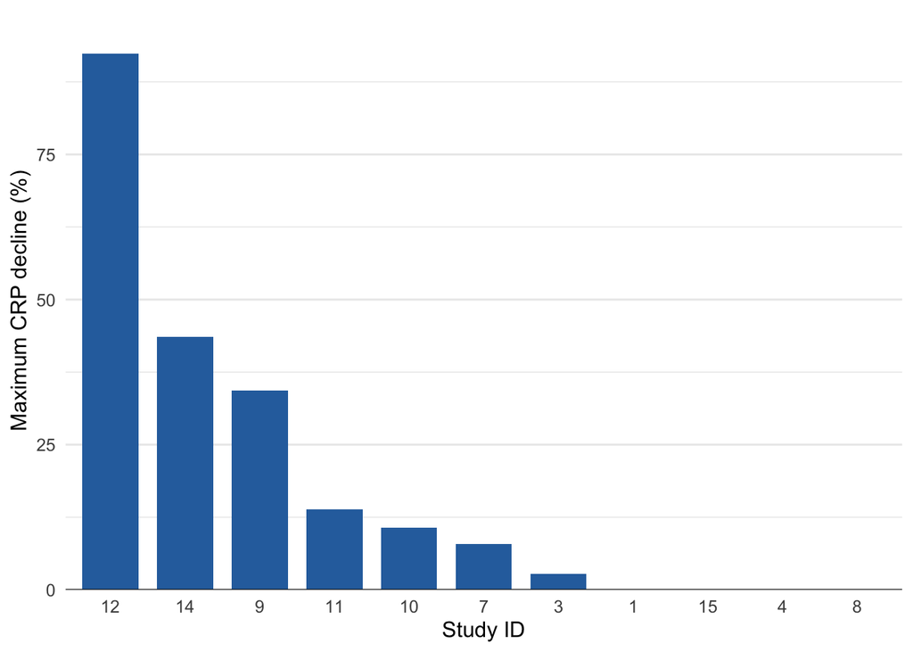

Figure 1. Maximum percent decline in C-reactive protein (CRP) from baseline during on-treatment assessment by enrolled patient (Cohort 1 low dose). Abbreviations: CRP, C-reactive protein.

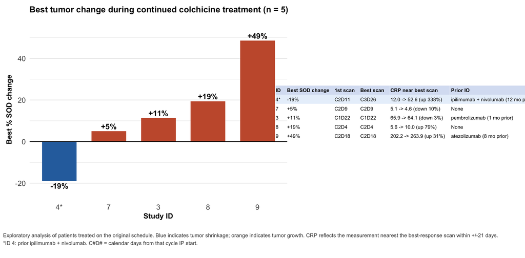

Figure 2. Best percent change in target-lesion sum of diameters during continued colchicine treatment. The waterfall plot shows the best percent change from baseline among five patients treated on the original schedule; the accompanying table summarizes scan timing, CRP change near the best-response scan, and prior immunotherapy exposure. One patient, ID 4, experienced tumor shrinkage of 19% after prior ipilimumab plus nivolumab, although CRP increased near the time of the scan. This post hoc analysis is hypothesis-generating only. Abbreviations: CRP, C-reactive protein; IO, immunotherapy; SOD, sum of diameters.

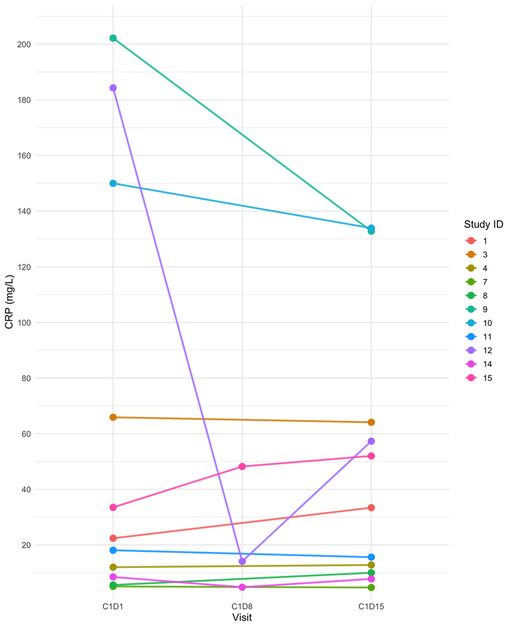

Figure 3. Longitudinal peripheral blood CRP (mg/L) across protocol C1 visits (baseline C1D1 and post-baseline C1D8/C1D15) for enrolled patients with serial C1 values. Abbreviations: CRP, C-reactive protein.

## General Toxicity Profile

Treatment-related adverse events (TRAE; attribution coded as Possible/Probable/Definite) are summarized by worst CTCAE grade per patient per preferred term (if multiple grades are recorded for the same term, only the maximum grade is counted).

Table 7. Treatment-related adverse events by CTCAE v5 preferred term and worst grade per patient (N = 11). Patients with any grade ≥3 event: 0%.

| Adverse event (CTCAE v5) | Grade | N (%) |
| --- | --- | --- |
| Diarrhea | Grade 1 | 3 (27.3%) |
| Diarrhea | Grade 2 | 1 (9.1%) |
| Hypokalemia | Grade 1 | 1 (9.1%) |
| Hyponatremia | Grade 1 | 1 (9.1%) |
| Nausea | Grade 1 | 1 (9.1%) |
| Vomiting | Grade 1 | 1 (9.1%) |
| Weight loss | Grade 1 | 1 (9.1%) |

## Pharmacokinetics and Pharmacodynamics

Pharmacokinetics were not evaluated. Pharmacodynamic assessments included CRP (primary), ferritin, and erythrocyte sedimentation rate (ESR) when collected per protocol.

Table 8. Pharmacodynamic laboratory values (all on-study assessments, enrolled patients).

| Marker | N | Median (IQR) |
| --- | --- | --- |
| CRP (mg/L) | 47 | 24.8 ( 9.5– 65.0) |
| ESR (mm) | 28 | 61.0 (44.2–117.8) |
| Ferritin (µg/dL) | 32 | 139.5 (82.8–246.2) |

Table 9. Pharmacodynamic decline from baseline to minimum post-baseline C1 value (C1D8/C1D15). Decline is bounded at 0% (no decline).

| Marker | N evaluable | Baseline median | Post-baseline minimum median | Median % decline (IQR) |
| --- | --- | --- | --- | --- |
| CRP (mg/L) | 11 | 22.4 | 15.6 | 7.8 (0.0–24.1) |
| Ferritin (µg/dL) | 2 | 265.5 | 153.0 | 35.0 (26.3–43.8) |

Ferritin evaluable count note: baseline-to-post C1 (D8/D15) ferritin was available for 2 patient(s); using any post-baseline visit (any cycle) would yield 8 patient(s).

Table 10. CRP pharmacodynamic response summary among evaluable patients.

| N evaluable | Decline ≥30%, n (%) | Decline ≥50%, n (%) | Median CRP % decline (IQR) |
| --- | --- | --- | --- |
| 11 | 3 (27.3%) | 1 (9.1%) | 7.8 (0.0–24.1) |

## Patient Status and Survival

Progression-free survival (PFS) and overall survival (OS) were not recorded on the dedicated case report forms in the available dataset. Endpoints below were derived per patient from: (1) RECIST 1.1 best overall response (progressive disease [PD] date); (2) protocol therapy discontinuation for documented progression; (3) final subject status and date of death or last contact. Time zero = first investigational product dispense date, or enrollment if missing.

Analyses in this section include only the 7 patients enrolled under the original indefinite colchicine schedule with serial imaging surveillance. The 4 patients enrolled on the fixed 2-week schedule lacked the same longitudinal imaging framework and are reported for CRP pharmacodynamics and safety only.

Table 11. Exploratory best overall response (RECIST 1.1) among original-schedule enrolled patients (Kaplan–Meier cohort).

| Best overall response (RECIST 1.1) | N patients | N (%) |
| --- | --- | --- |
| SD | 3 | 3 (42.9%) |
| Not assessed | 2 | 2 (28.6%) |
| PD | 2 | 2 (28.6%) |

Table 12. Exploratory progression-free survival and overall survival summary (Kaplan–Meier medians; original-schedule cohort, n = 7).

[output not shown]

Table 13. Patient-level progression-free survival and overall survival among original-schedule enrolled patients (derived from RECIST, discontinuation, and final status fields).

| Study ID | Index date | Best RECIST on study | PFS event | PFS date | PFS (months) | OS event | OS date | OS (months) | Final status |
| --- | --- | --- | --- | --- | --- | --- | --- | --- | --- |
| 1 | 2022-02-17 | Not assessed | Censored | 2022-03-27 | 1.2 | Death | 2022-03-27 | 1.2 | Dead |
| 3 | 2022-03-08 | SD | Progression | 2022-04-05 | 0.9 | Censored | 2023-03-29 | 12.7 | Not recorded |
| 4 | 2022-03-17 | SD | Censored | 2022-06-06 | 2.7 | Censored | 2023-05-04 | 13.6 | Not recorded |
| 7 | 2022-06-17 | PD | Progression | 2022-09-01 | 2.5 | Censored | 2022-09-13 | 2.9 | Not recorded |
| 8 | 2022-07-14 | SD | Progression | 2022-08-29 | 1.5 | Death | 2022-10-03 | 2.7 | Dead |
| 9 | 2022-07-21 | PD | Progression | 2022-09-01 | 1.4 | Death | 2022-09-15 | 1.8 | Dead |
| 10 | 2022-07-19 | Not assessed | Progression | 2022-08-02 | 0.5 | Death | 2023-04-24 | 9.2 | Dead |

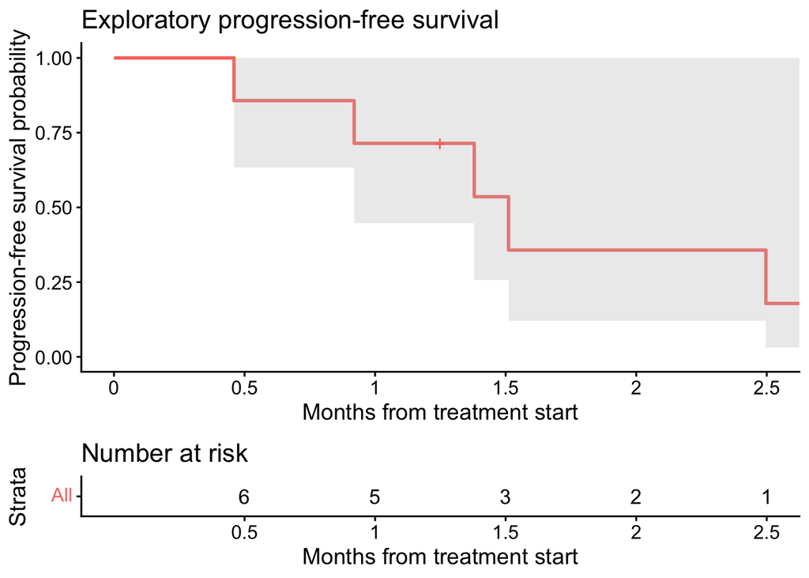

Figure 4. Progression-free survival (Kaplan–Meier) from treatment start among patients enrolled under the original indefinite colchicine schedule with surveillance imaging (n = 7; exploratory; not powered). PFS events: RECIST PD or discontinuation for progression. Abbreviations: PFS, progression-free survival; PD, progressive disease; RECIST, Response Evaluation Criteria in Solid Tumors.

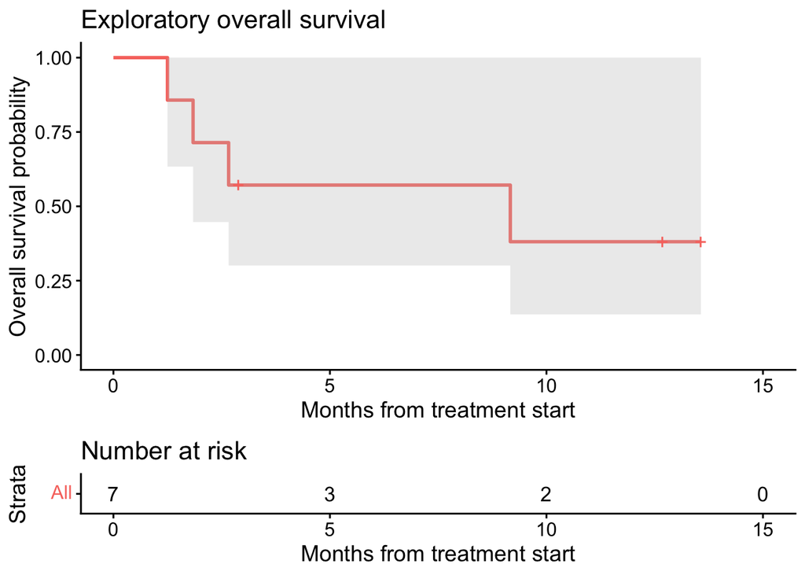

Figure 5. Overall survival (Kaplan–Meier) from treatment start among patients enrolled under the original indefinite colchicine schedule with surveillance imaging (n = 7; exploratory; not powered). Abbreviations: OS, overall survival.

*These survival analyses are descriptive and underpowered (Kaplan–Meier cohort n = 7; total enrolled n = 11). Medians and curves should be interpreted cautiously; several patients lack formal final-status forms but have tumor assessment or visit dates used for censoring. Patients on the fixed 2-week schedule (n = 4) are excluded because they did not receive the same longitudinal imaging surveillance framework.*

## Statistical Analysis

### Primary hypothesis and test

The primary endpoint was maximum percent decline in peripheral blood CRP from cycle 1 day 1 to the lowest on-treatment value during post-baseline cycle 1 visits (cycle 1 day 8 or day 15). We tested the prespecified null hypothesis H0: mean maximum CRP decline = 0 against the one-sided alternative H1: mean decline > 0 using a one-sample *t*-test.

[Protocol STUDY-21-001175, version 3.0 (22 May 2023)](https://clinicaltrials.gov/study/NCT05279690) Section 12.4 prespecified Bonferroni adjustment of overall type I error at 0.05 across two planned Cohort 1 primary tests (low-dose vs 0 and high-dose vs low-dose), yielding α = 0.025 for each test. Because the high-dose sequential arm did not enroll, only the low-dose one-sample test was performed; for this completed analysis we applied one-sided α = 0.05 rather than the Bonferroni-adjusted α = 0.025.

The observed mean decline was 18.7% (SD 28.5%); one-sided *p* = 0.028, which rejects H0 at α = 0.05.

### Sample size and power

The protocol planned 15 evaluable patients in the low-dose cohort (80% power to detect a standardized effect size of 0.80 at α = 0.025). 11 evaluable patients were analyzed. Post-hoc power to detect the observed effect (standardized effect size d ≈ 0.65) at α = 0.05 was approximately 65%. At the full planned sample size of 15 with the same observed effect, post-hoc power at α = 0.05 would have been approximately 78%.

### Exploratory and safety analyses

Exploratory progression-free and overall survival estimates used the Kaplan–Meier method among the 7 patients enrolled under the original indefinite-treatment schedule with serial imaging surveillance only. PFS and OS were derived from RECIST 1.1 assessments, protocol therapy discontinuation for progression, and final subject status when dedicated progression forms were incomplete. Treatment-related adverse events required Possible, Probable, or Definite attribution to colchicine and were summarized by CTCAE v5.0 preferred term and worst grade per patient. Analyses followed [protocol STUDY-21-001175, version 3.0 (22 May 2023)](https://clinicaltrials.gov/study/NCT05279690) Section 12. [Supplementary statistical methods and analysis output](https://alexanderb95-jpg.github.io/colchicine-ctr-stats/statistical-analysis.html) are available separately.

## Appendix: Included Subjects Dataset

Table 14. Subject-level dataset for patients included in primary endpoint analysis (N = 11).

| Study ID | Primary cancer type | Age (years) | Sex | ECOG | Prior systemic lines | CRP baseline C1D1 (mg/L) | CRP C1D8 (mg/L) | CRP C1D15 (mg/L) | Lowest post-baseline CRP (mg/L) | Max CRP decline (%) | N post-baseline CRP values | PFS event | PFS (months) | OS event (death) | OS (months) |
| --- | --- | --- | --- | --- | --- | --- | --- | --- | --- | --- | --- | --- | --- | --- | --- |
| 1 | Ovarian cancer | 70 | Female | 1 | 2 | 22.4 | NA | 33.4 | 33.4 | 0.0 | 1 | No | 1.2 | Yes | 1.2 |
| 3 | Urothelial carcinoma | 67 | Male | 1 | 4 | 65.9 | NA | 64.1 | 64.1 | 2.7 | 1 | Yes | 0.9 | No | 12.7 |
| 4 | Urothelial carcinoma | 78 | Female | 1 | 4 | 12.0 | NA | 12.8 | 12.8 | 0.0 | 1 | No | 2.7 | No | 13.6 |
| 7 | Head and neck squamous cell carcinoma | 70 | Female | 1 | 2 | 5.1 | NA | 4.7 | 4.7 | 7.8 | 1 | Yes | 2.5 | No | 2.9 |
| 8 | Rectal adenocarcinoma | 43 | Male | 0 | 11 | 5.6 | NA | 10.0 | 10.0 | 0.0 | 1 | Yes | 1.5 | Yes | 2.7 |
| 9 | Ovarian cancer | 78 | Female | 0 | 3 | 202.2 | NA | 132.8 | 132.8 | 34.3 | 1 | Yes | 1.4 | Yes | 1.8 |
| 10 | Urothelial carcinoma | 84 | Male | 1 | 4 | 150.0 | NA | 133.9 | 133.9 | 10.7 | 1 | Yes | 0.5 | Yes | 9.2 |
| 11 | Cervical cancer | 71 | Female | 0 | 0 | 18.1 | NA | 15.6 | 15.6 | 13.8 | 1 | NA | NA | NA | NA |
| 12 | Anal squamous cell carcinoma | 42 | Male | 0 | 2 | 184.3 | 14.1 | 57.3 | 14.1 | 92.3 | 2 | NA | NA | NA | NA |
| 14 | Ovarian cancer | 70 | Female | 0 | 2 | 8.5 | 4.8 | 7.8 | 4.8 | 43.5 | 2 | NA | NA | NA | NA |
| 15 | Ovarian cancer | 57 | Female | 2 | 14 | 33.5 | 48.2 | 52.0 | 48.2 | 0.0 | 2 | NA | NA | NA | NA |

*Statistical methods follow [protocol STUDY-21-001175, version 3.0 (22 May 2023)](https://clinicaltrials.gov/study/NCT05279690) Section 12.4.*